# HW6 Revised - TPO Mill Size Analysis

Final Project Draft for DACCS 601

Ian Kennedy  
2022-04-14

# 1 Introduction

For my final project I am using a data set from the research lab (FFRC) I’ve been working with for the past few years. In short, the Family Forest Research Center (FFRC), in coordination with the USDA Forest Service, implements the annual Timber Products Output (TPO) survey, which attempts to track timber procurement and lumber production at mills throughout a host of states in the north/northeastern US. Findings from this analysis will assist in answering questions surrounding the introduction of a volume-based threshold relating to survey inclusion. Specifically, through this analysis I will attempt to answer the following questions:

1. In an effort to hone surveying efforts towards commercial mills, should small-production/hobby mills be excluded from future survey attempts?
2. If yes, what is the minimum volume (i.e. omission threshold) that mills will need to have procured to be included in survey efforts?
3. What impact does shifting a potential omission threshold have on the total volume and number of mills that are surveyed?

Before delving into the project, a bit of background on the TPO Survey is necessary. While the TPO Survey is conducted annually, most mills within the sample do not receive a survey every year. Rather, each year ‘filtering’ of the sample frame is conducted prior to survey dissemination. This ‘filtering’ is done on a state-by-state basis, and uses a volume-based weighting system to pull a certain number of mills for the given year. In other words, high-volume mills are more likely to be surveyed than low-volume mills within the same state. Thus, it is possible that a mill could go several years without being surveyed, or vice-versa (surveyed each and every year). On top of the state-level ‘filtering’, differences in state-level mill counts also play a role. Mills located in states with low mill counts (i.e. Rhode Island, New Jersey, Delaware, etc.) are more likely to be surveyed than similar-volume mills in states with far higher mill counts (i.e. Michigan, Pennsylvania, etc.). This is to ensure that every state within the sample has at least a few mills included in survey attempts each and every year.

The ‘filtering’ discussed above does not impact the process through which an omission threshold analysis is conducted. However it does present one caveat that must be considered prior to usage of a threshold, which will be discussed in greater detail in the ‘Data’ section below.

# 2 Data

Now on to the aforementioned caveat. Because ‘filtering’ allows for the possibility that a mill is not surveyed for multiple years, many mills’ reported volumes are simply estimates based on nearby mills of similar size, or worse, are rollover-data from the last time they did respond. On top of this, with a response rate ~50%, even if a mill is chosen for survey inclusion every year, they may not respond. Thus, prior to utilizing any omission thresholds, further analysis of potentially omitted mills is necessary. This issue is outside of the breadth of this analysis as it will need to be addressed manually by Forest Service staff, but is important to highlight.

## 2.1 Reading in Data & Setting up ‘State_Code_Conversion’

The following lines of code are used to read in the dataset and to set up the ‘State_Code_Conversion’ function that will be utilized throughout the analysis. Because each mill contains a variable ‘MILL_STATECD’, which is simply the numeric state code for the state the mill is located, the ‘State_Code_Conversion’ function creates a new column, ‘MILL_STATE’, containing the two-letter abbreviation for the respective state.

```r
TPO_Data <- read_excel(path = "C:/Users/kenne/Documents/R_Workspace/TPO_Sample.xlsx")

State_Code_Conversion <- function(Data){
   Data %>%
    mutate(MILL_STATE = case_when(MILL_STATECD == 9 ~ "CT",
                                MILL_STATECD == 10 ~ "DE",
                                MILL_STATECD == 17 ~ "IL",
                                MILL_STATECD == 18 ~ "IN",
                                MILL_STATECD == 19 ~ "IA",
                                MILL_STATECD == 20 ~ "KS",
                                MILL_STATECD == 23 ~ "ME",
                                MILL_STATECD == 24 ~ "MD",
                                MILL_STATECD == 25 ~ "MA",
                                MILL_STATECD == 26 ~ "MI",
                                MILL_STATECD == 27 ~ "MN",
                                MILL_STATECD == 29 ~ "MO",
                                MILL_STATECD == 31 ~ "NE",
                                MILL_STATECD == 33 ~ "NH",
                                MILL_STATECD == 34 ~ "NJ",
                                MILL_STATECD == 36 ~ "NY",
                                MILL_STATECD == 38 ~ "ND",
                                MILL_STATECD == 39 ~ "OH",
                                MILL_STATECD == 42 ~ "PA",
                                MILL_STATECD == 44 ~ "RI",
                                MILL_STATECD == 46 ~ "SD",
                                MILL_STATECD == 50 ~ "VT",
                                MILL_STATECD == 54 ~ "WV",
                                MILL_STATECD == 55 ~ "WI"))
}
```

## 2.2 Calculating Initial Results

The next few lines of code use the dataset to calculate a few meaningful values. For each of these calls, ‘MILL_STATUS_CD’ is filtered to only include observations listed as 1 (new), 2 (active), or NA (blank). All other values, which represent closed, idle, or out of business operations, were excluded from these measurements.

The first chunk finds the sum of all mill volumes, stored in a variable named ‘TOT_Volume’. The second chunk finds the total number of active/new mills in the sample, stored in a variable named ‘TOT_Mills’. The last chunk filters the data set to include only mills with a reported volume >= 100,000,000 BF, stored in a variable named ‘TOT_Mills_High_Vol’.

```r
#Calculate the sum of all Mill Volumes

TPO_Data %>%
  filter(is.na(MILL_STATUS_CD)| MILL_STATUS_CD == 2| MILL_STATUS_CD == 1) %>%
  select(TOT_BF)%>%
  sum(na.rm = FALSE) -> TOT_Volume

TPO_Data <- State_Code_Conversion(TPO_Data)

#Calculate Total # of mills

TPO_Data %>%
    filter(is.na(MILL_STATUS_CD)| MILL_STATUS_CD == 2| MILL_STATUS_CD == 1)%>%
    nrow() -> TOT_Mills
TOT_Mills <- as.numeric(unlist(TOT_Mills))

#Filter mills with BF > 100,000,000

TPO_Data %>%
  filter(TOT_BF >= 100000000, is.na(MILL_STATUS_CD)|MILL_STATUS_CD == 2|MILL_STATUS_CD == 1)%>%
  nrow -> TOT_Mills_High_Vol
TOT_Mills_High_Vol <- as.numeric(unlist(TOT_Mills_High_Vol))
```

### 2.2.1 Printing Initial Results

- Total # of mills in sample = 3033
- Total volume in sample = 402462778058.995 BF
- Total # of mills with volume > 100,000,000 BF = 83

## 2.3 Omission Threshold Functions and Setup

The chunk below starts the process of creating omission thresholds, first creating a new column in the dataset named ‘Volume_Code’. With thresholds starting at 1,000 BF, and then incrementing by 5,000 BF (from 5,000 BF to 50,000 BF), the ‘Volume_Code’ variable takes the value of 1/10,000th of the threshold. In other words, any mill with a reported volume between 5,000-10,000 receives a ‘1’, whereas any mill with a reported volume between 10,000-15,000 receives a ‘1.5’. Any mills above the final threshold value (50,000 BF) receive a ‘99’, while mills reporting 0 BF/blanks receive a ‘0’.

From here, the ‘Threshold_Data’ df is created by filtering for mills whose ‘Volume_Code’ value is not 99 or 0.

Next, two more functions are established, ‘Threshold_Mills’ and ‘Threshold_Volume’, each measuring different values. Both contain two arguments, ‘Data’ and ‘Volumes’…‘Data’ is simply the dataset to be utilized, while ‘Volumes’ refers to a vector of threshold volumes.

```r
#Create Omission Thresholds
  #If changing thresholds, make sure to update Function_Volumes.
  #If new thresholds are not 1/10000th of top-bounding threshold, make sure to update for-in loop.

TPO_Data <- TPO_Data %>%
  mutate(Volume_Code = case_when(TOT_BF >= 50000 ~ 99,
                                 TOT_BF < 50000 & TOT_BF >= 45000 ~ 5,
                                 TOT_BF < 45000 & TOT_BF >= 40000 ~ 4.5,
                                 TOT_BF < 40000 & TOT_BF >= 35000 ~ 4,
                                 TOT_BF < 35000 & TOT_BF >= 30000 ~ 3.5,
                                 TOT_BF < 30000 & TOT_BF >= 25000 ~ 3,
                                 TOT_BF < 25000 & TOT_BF >= 20000 ~ 2.5,
                                 TOT_BF < 20000 & TOT_BF >= 15000 ~ 2,
                                 TOT_BF < 15000 & TOT_BF >= 10000 ~ 1.5,
                                 TOT_BF < 10000 & TOT_BF >= 5000 ~ 1,
                                 TOT_BF < 5000 & TOT_BF > 1000 ~ 0.5,
                                 TOT_BF < 1000 & TOT_BF > 0 ~ 0.1,
                                 TOT_BF == 0 ~ 0)) %>%
  filter(is.na(MILL_STATUS_CD)| MILL_STATUS_CD == 2| MILL_STATUS_CD == 1)


Threshold_Data <- TPO_Data %>%
  filter(Volume_Code != 99 & Volume_Code !=0)

#Create Functions for Mill Count & Volume Omission Data

Threshold_Mills <- function(Data, Volumes){
  Data %>%
    filter(Volume_Code %in% Volumes) %>%
    select(TOT_BF) %>%
    nrow -> placeholder
  placeholder <- as.numeric(unlist(placeholder))
}

Threshold_Volume <- function(Data, Volumes){
  Data %>%
    filter(Volume_Code %in% Volumes) %>%
    select(TOT_BF) %>%
    sum(na.rm = TRUE)
}
```

### 2.3.1 For-In Loop

The code snippet below first establishes ‘Function_Volumes’ by creating a vector of values containing the unique values left in the ‘Volume_Code’ column (99s and 0s were previously removed).

From there, a for-in loop is used to cycle through each value within ‘Function_Volumes’. With each iteration, two numeric variables are outputted, ‘TOT_Mill_Omit_[Mill Count]’ and ‘TOT_Volume_Omit_[Volume Omitted]’. The ’Function_Volumes[i]*10000’ piece multiplies the value by 10,000 to return a variable named based on the threshold in question. The value of these variables are calculated by using the respective function (Threshold_Mills or Threshold_Volume) for each of the iterations. By specifying a volume argument of ‘Function_Volumes[1:i]’ for each, quantities are aggregated from previous iterations. In other words, a mill reporting 3,000 BF will not only be omitted from a 5,000 BF threshold, but also from a 10,000, 15,000, 20,000, etc. BF threshold.

```r
#For-Loop for Mill & Volume Omission Data
Function_Volumes <- c(.1,seq(0.5,5,by = 0.5))

for (i in 1:length(Function_Volumes)){
  assign(paste0("TOT_Mill_Omit_", Function_Volumes[i]*10000), value = Threshold_Mills(Threshold_Data, Function_Volumes[1:i]))
  assign(paste0("TOT_Volume_Omit_", Function_Volumes[i]*10000), value = Threshold_Volume(Threshold_Data, Function_Volumes[1:i]))
}
```

### 2.3.2 Vector Creation

Following the for-in loop, 11 of each of the ‘TOT_Mill_Omit_[Mill Count]’ and ‘TOT_Volume_Omit_[Volume Omitted]’ variables are created. From there, the Mill Count variables are added to a vector named ‘Omit_Mill_Count_Vector’ and the Omitted Volume variables are added to a vector named ‘Omit_Volume_Vector’. Additionally, two vectors of length 11, containing the total sample volume (‘TOT_Volume’) and number of mills within the sample (‘TOT_Mills’), are also created.

Next, the ‘Omit_DF’ df is created using the 4 vectors established above, with rows named based on the threshold in question. Also, a new column (‘Percent_Omitted’) is added by dividing the Omitted Mill Count (‘Omit_Mill_Count_Vector’) by the total Mill Count in the sample (‘TOT_Mill_Vector’), and multiplying by 100.

Using the ‘Omit_DF’ df, an omission threshold table is created using the kable() function, removing the columns relating to Total Volume and Total Mill Count (4 & 5).

Again using the ‘Omit_DF’ df, a scatter/line plot is drawn based on ‘Percent_Omitted’ (x) and ‘Omit_Volume_Vector’ (y). Before doing so, the ‘Omit_Vec’ vector is created and binded to ‘Omit_DF’ using the cbind() function. The plot’s code contains a few other specifications, all of which are included to clean up the aesthetics of the plot.

Finally, all of the now-unneeded vectors are removed from the local environment.

```r
# Create Vectors for Omitted Mill Counts and Volumes
# Need to change these vectors if changing omission thresholds

Omit_Mill_Count_Vector <- c(TOT_Mill_Omit_1000, TOT_Mill_Omit_5000, TOT_Mill_Omit_10000, TOT_Mill_Omit_15000, TOT_Mill_Omit_20000, TOT_Mill_Omit_25000, TOT_Mill_Omit_30000, TOT_Mill_Omit_35000, TOT_Mill_Omit_40000, TOT_Mill_Omit_45000, TOT_Mill_Omit_50000)

Omit_Volume_Vector <- c(TOT_Volume_Omit_1000,TOT_Volume_Omit_5000, TOT_Volume_Omit_10000, TOT_Volume_Omit_15000, TOT_Volume_Omit_20000, TOT_Volume_Omit_25000, TOT_Volume_Omit_30000, TOT_Volume_Omit_35000, TOT_Volume_Omit_40000, TOT_Volume_Omit_45000, TOT_Volume_Omit_50000)

TOT_Volume_Vector <- c(TOT_Volume, TOT_Volume, TOT_Volume, TOT_Volume, TOT_Volume, TOT_Volume, TOT_Volume, TOT_Volume, TOT_Volume, TOT_Volume, TOT_Volume)

TOT_Mill_Vector <- c(TOT_Mills, TOT_Mills, TOT_Mills, TOT_Mills, TOT_Mills, TOT_Mills, TOT_Mills, TOT_Mills, TOT_Mills, TOT_Mills, TOT_Mills)

# Convert Vectors to Dataframe

Omit_DF <- data.frame(Omit_Mill_Count_Vector, Omit_Volume_Vector, TOT_Volume_Vector, TOT_Mill_Vector, row.names = c('1,000 BF cut-off','5,000 BF cut-off', '10,000 BF cut-off', '15,000 BF cut-off', '20,000 BF cut-off', '25,000 BF cut-off', '30,000 BF cut-off', '35,000 BF cut-off', '40,000 BF cut-off', '45,000 BF cut-off', '50,000 BF cut-off')) %>%
  mutate(Percent_Omitted = Omit_Mill_Count_Vector/TOT_Mill_Vector*100)

# Produce Omission Table and Plot

kable(Omit_DF, digits = 3, align = "ccccc", col.names = c("Omitted Mill Count", "Omitted Volume (BF)", "Total Volume (BF) in Sample", "Total Mill Count in Sample", "Percent of Mills Omitted"), caption = "Omissions by Varying Volume Baselines", format.args = list(big.mark = ",", scientific = FALSE)) %>%
  kable_styling(font_size = 16) %>%
  column_spec(column = 1, bold = TRUE) %>%
  remove_column(columns = c(4,5))
```

Table 1: Omissions by Varying Volume Baselines

|  | Omitted Mill Count | Omitted Volume (BF) | Percent of Mills Omitted |
| --- | --- | --- | --- |
| 1,000 BF cut-off | 12 | 5,171.91 | 0.396 |
| 5,000 BF cut-off | 61 | 131,815.16 | 2.011 |
| 10,000 BF cut-off | 212 | 1,090,339.66 | 6.990 |
| 15,000 BF cut-off | 395 | 3,050,295.78 | 13.023 |
| 20,000 BF cut-off | 427 | 3,595,382.92 | 14.078 |
| 25,000 BF cut-off | 534 | 5,869,227.26 | 17.606 |
| 30,000 BF cut-off | 599 | 7,560,188.15 | 19.749 |
| 35,000 BF cut-off | 646 | 9,058,803.05 | 21.299 |
| 40,000 BF cut-off | 657 | 9,474,340.40 | 21.662 |
| 45,000 BF cut-off | 678 | 10,359,047.47 | 22.354 |
| 50,000 BF cut-off | 694 | 11,116,999.56 | 22.882 |

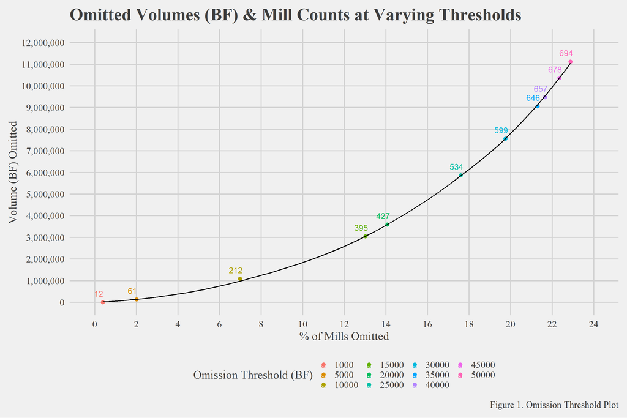

```r
Omit_Vec <- c(1000,seq(5000,50000, by = 5000))
Omit_DF <- cbind(Omit_DF, Omit_Vec)

Omit_DF %>%
  ggplot(aes(Percent_Omitted, Omit_Volume_Vector, color = factor(Omit_Vec))) +
  geom_point(size = 3) +
  geom_smooth(size = .8, se = FALSE, color = 'black') +
  scale_x_continuous(breaks = c(seq(0,24,2)), limits = c(0,24)) +
  scale_y_continuous(labels = scales::comma, limits = c(0,12000000), breaks = c(seq(0,12000000,1000000))) +
  scale_color_discrete(name = "Omission Threshold (BF)") +
  labs(title = "Omitted Volumes (BF) & Mill Counts at Varying Thresholds", caption = "Figure 1. Omission Threshold Plot") +
  geom_text(aes(label = Omit_Mill_Count_Vector), size =  5,nudge_y = 400000, nudge_x = -.2) +
  theme_fivethirtyeight(base_size = 20, base_family = 'serif')+
  theme(axis.title = element_text(family = 'serif', size = 20)) + ylab('Volume (BF) Omitted') + xlab('% of Mills Omitted')
```

```r
# Remove Unneeded Vectors

rm(Omit_Mill_Count_Vector, Omit_Volume_Vector, TOT_Volume_Vector, TOT_Mill_Vector, Omit_Vec, i, Function_Volumes)

rm(TOT_Mill_Omit_1000,TOT_Mill_Omit_5000, TOT_Mill_Omit_10000, TOT_Mill_Omit_15000, TOT_Mill_Omit_20000, TOT_Mill_Omit_25000, TOT_Mill_Omit_30000, TOT_Mill_Omit_35000, TOT_Mill_Omit_40000, TOT_Mill_Omit_45000, TOT_Mill_Omit_50000)

rm(TOT_Volume_Omit_1000, TOT_Volume_Omit_5000, TOT_Volume_Omit_10000, TOT_Volume_Omit_15000, TOT_Volume_Omit_20000, TOT_Volume_Omit_25000, TOT_Volume_Omit_30000, TOT_Volume_Omit_35000, TOT_Volume_Omit_40000, TOT_Volume_Omit_45000, TOT_Volume_Omit_50000)
```

## 2.4 State-Level Omission Thresholds

### 2.4.1 Creation of State-Level Omission Function

In the following chunk, the ‘State_Omit_Count_Levels’ df is created by selecting the columns of interest from ‘Threshold_Data’, grouping by State (‘MILL_STATECD’) and Omission Threshold (‘Volume_Code’) to find the # of mills omitted at each threshold, converting the ‘Volume_Code’ variable to BF units by multiplying the value by 10,000, and then using the ‘State_Code_Conversion’ function to convert state codes to the respective state abbreviation.

With aggregate omission threshold data (across all states), the next step in this analysis is to produce similar plots and tables at the state level. To do this, I first created a function, ‘Sum_Threshold_Volumes_by_State’, which is broken down in further detail below:

[output not shown]

```r
# Find State-by-State Omitted Volume Totals

State_Omit_Count_Levels <- Threshold_Data %>%
  select(MILL_STATECD, MTC:TOT_BF_LOG, Volume_Code) %>%
  group_by(MILL_STATECD, Volume_Code) %>%
  summarize(Mill_Count = n()) %>%
  mutate(Volume_Code = Volume_Code*10000)
State_Omit_Count_Levels <- State_Code_Conversion(State_Omit_Count_Levels)

# Function for summing Omitted Volume by Threshold

Sum_Threshold_Volumes_by_State <- function(Data){
  for (v in 1:length(Data$`Omission Threshold (BF)`)){
    if (v == 1){
      next
    } else if (Data$State[v] != Data$State[v-1]){
      next
    } else if (Data$`Omission Threshold (BF)`[v] > Data$`Omission Threshold (BF)`[v-1]){
      Data$`Volume Omitted (BF)`[v] + Data$`Volume Omitted (BF)`[v-1] -> Data$`Volume Omitted (BF)`[v]
    } else{
      break
    }
  }
  Data
}
```

### 2.4.2 Tidying of State-Level Data Frame

The next step in the analysis is to create a state-level df containing omission threshold mill counts and omitted volumes. I first used the ‘State_Code_Conversion’ function to convert state codes to the respective state abbreviation within the ‘Threshold_Data’ df. Next, I created a df containing total reported/estimated volumes for each state (‘State_Volumes’). From there I created the ‘Omission_Data’ df by grouping by state and omission threshold, summing volume (‘TOT_BF’) for each grouping, creating the ‘Omission Threshold (BF)’ column/dropping the ‘Volume_Code’ column, and finally joining the state volume totals (‘State_Volumes’) to the df with a left_join() call. The df is then used as an input to the ‘Sum_Threshold_Volumes_by_State’ function discussed above.

Following usage of the function, a new variable (‘% of Volume Omitted’) is added by dividing the omitted volume by the total state volume, and columns are reordered.

At this point the df contains state-level omitted volume data, though does not contain omitted mill count information. Thus the ‘State_Omit_Count_Levels’ df (created in the previous chunk) is also joined to ‘Omission_Data’, again using a left_join() call.

Finally, a ‘state_Count’ variable is added by summing omitted mill counts, grouped by state. This variable represents the total number of mills omitted at the upper-most volume threshold applied to the state in question.

```r
#Specify Column Order

col_order <- c("State", "Omission Threshold (BF)", "Volume Omitted (BF)",
               "Total State Volume (BF)", "% of Volume Omitted")

Threshold_Data <- State_Code_Conversion(Threshold_Data)

# Find Total State Volumes

State_Volumes <- TPO_Data %>%
  select('MILL_STATE', 'TOT_BF', 'TOT_BF_LOG') %>%
  group_by(MILL_STATE) %>%
  summarize(State_Volume = sum(TOT_BF))

# Create Omitted Volume by State DF

Omission_Data <- Threshold_Data %>%
  group_by(MILL_STATE, Volume_Code) %>%
  summarize('Volume Omitted (BF)' = sum(TOT_BF)) %>%
  mutate('Omission Threshold (BF)' = Volume_Code*10000) %>%
  select(-Volume_Code) %>%
  left_join(State_Volumes, by = 'MILL_STATE') %>%
  rename('Total State Volume (BF)' = 'State_Volume', 'State' = 'MILL_STATE') %>%
  ungroup()

# Sum Volumes by State/Threshold & Create % field comparing Omitted Threshold Volume to Total State Volume

Omission_Data <- Omission_Data %>%
  Sum_Threshold_Volumes_by_State() %>%
  mutate('% of Volume Omitted' = `Volume Omitted (BF)`/`Total State Volume (BF)` * 100)

# Reorder columns

Omission_Data <- Omission_Data[, col_order]
rm(col_order)

# Join Omission Data with Omitted Mill Counts

Omission_Data <- Omission_Data %>%
  left_join(State_Omit_Count_Levels, by = c('State' = 'MILL_STATE', 'Omission Threshold (BF)' = 'Volume_Code'))

Omission_Data <- Omission_Data %>%
  group_by(State) %>%
  mutate(state_Count = sum(Mill_Count)) %>%
  select(-MILL_STATECD)
```

### 2.4.3 Aggregating State Omission Volumes and Mill Counts

Because the ‘Omission_Data’ df is only populated for thresholds (rows) from which a mill has been omitted, measures of volumes and mill counts at each threshold again must be aggregated, this time on a state-by-state basis. In other words, assuming a state only contains a few mills reporting under 50,000 BF (the upper most threshold), and each of these mills falls within the 10,000-15,000 BF range (categorized under the 15,000 BF threshold). Only the 15,000 BF threshold row would be present for the state, leading to inaccurate visualization…As mentioned above, a mill within the 10,000-15,000 BF range will not only be omitted if using a 15,000 BF threshold, but also a 20,000 BF, 25,000 BF, 30,000 BF, etc. threshold.

To fix this problem, a blank template of the ‘Omission_Data’ df is read in, and joined to the existing Omission_Data. This template contains all of the same columns, though has rows for each of the 11 respective omission thresholds for each state. After joining, two for-in/if-else statements are used to aggregate volumes and mill counts on a state-by-state basis. The comments within the chunk provide an explanation behind the reasoning for each if/else if statements.

Once the for-in/if-else statements are run, all NA values are changed to zeros, and the ‘Omission_Threshold’ column is renamed for usage in the Visualization section.

```r
#Read In Omission Template

Omission_Data <- read_csv("C:/Users/kenne/Documents/R_Workspace/Omission_Data.csv") %>%
  left_join(Omission_Data, by = c('State' ,'Omission_Threshold' = 'Omission Threshold (BF)'))


#For Loop to Create State Level Omission Table with Unused Thresholds

for (i in 1:length(Omission_Data$Omission_Threshold)){
  if (i == 1){
    #Skip the first row
    next
  }else if (Omission_Data$State[i] != Omission_Data$State[i-1]){
    #Skip row if jumping to a new state
    next
  }else if (is.na(Omission_Data$`Volume Omitted (BF)`[i] & is.na(Omission_Data$`Volume Omitted (BF)`[i-1]))){
    #Skip row if current & previous rows are NAs
    next
  }else if (!is.na(Omission_Data$`Volume Omitted (BF)`[i]) & is.na(Omission_Data$`Volume Omitted (BF)`[i-1])){
    #Skip row if current row is not NA but previous row is NA
    next
  }else if (is.na(Omission_Data$`Volume Omitted (BF)`[i]) & !is.na(Omission_Data$`Volume Omitted (BF)`[i-1])){
    #Copy Omission Volume, Total State Volume, & % of Volume Omitted if current row is NA but previous row is not.
    Omission_Data[i,3:5] <- Omission_Data[i-1,3:5]
    next
  }
}

#For Loop to Aggregate Omitted Mill Counts

for (i in 1:length(Omission_Data$Mill_Count)){
  if (i == 1){
    #Skip the first row
    next
  }else if (Omission_Data$State[i] != Omission_Data$State[i-1]){
    #Skip row if jumping to a new state
    next
  }else if (is.na(Omission_Data$Mill_Count[i] & is.na(Omission_Data$Mill_Count[i-1]))){
    #Skip row if current & previous rows are NAs
    next
  }else if (!is.na(Omission_Data$Mill_Count[i]) & is.na(Omission_Data$Mill_Count[i-1])){
    #Skip row if current row is not NA but previous row is NA
    next
  }else if (is.na(Omission_Data$Mill_Count[i]) & !is.na(Omission_Data$Mill_Count[i-1])){
    #Copy Mill Count info from previous row if current row is NA but previous is not NA
    Omission_Data$Mill_Count[i] <- Omission_Data$Mill_Count[i-1]
    next
  }else if (!is.na(Omission_Data$Mill_Count[i]) & !is.na(Omission_Data$Mill_Count[i-1]))
    #Copy Mill Count info from previous row if current & previous rows are NAs
    Omission_Data$Mill_Count[i] <- Omission_Data$Mill_Count[i] + Omission_Data$Mill_Count[i-1]
  next
}

rm(i)

#Change NA values to 0
Omission_Data[is.na(Omission_Data)] = 0

#Rename Omission Threshold column
Omission_Data <- Omission_Data %>%
  rename("Omission Threshold (BF)" = "Omission_Threshold")
```

# 3 Visualization

## 3.1 State-Level Omission Threshold Plots, Table, & Code

Using the ‘Omission_Data’ df, a few plots are created along with a table depicting the information within the df. Additionally, click this link to view an interactive omission threshold web map created with Tableau.

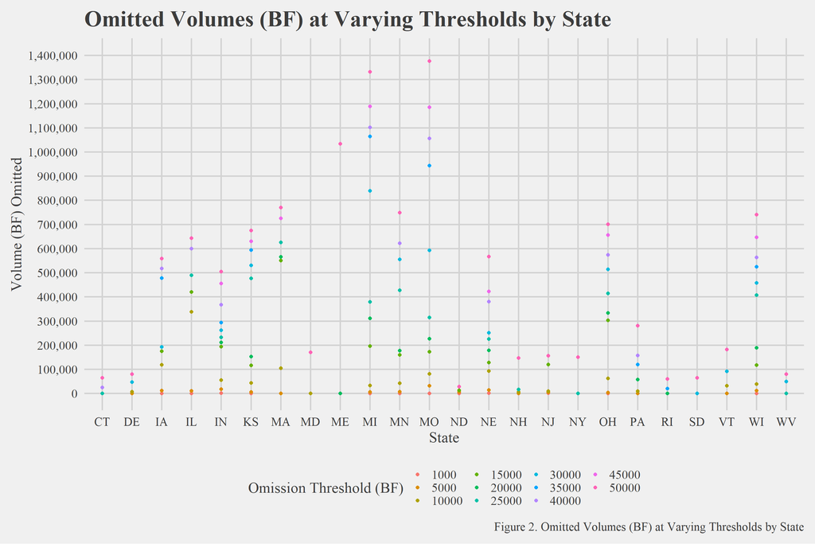

```r
# Omission Plots

Omission_Data %>%
  ggplot(aes(State,`Volume Omitted (BF)`, color = factor(`Omission Threshold (BF)`))) +
  geom_point(size = 2) +
  scale_y_continuous(labels = scales::comma, limits = c(0,1400000), breaks = c(seq(0,1400000,100000))) +
  scale_color_discrete(name = "Omission Threshold (BF)") +
  labs(title = "Omitted Volumes (BF) at Varying Thresholds by State", y = "Omitted Volume (BF)", x = "State", caption = "Figure 2. Omitted Volumes (BF) at Varying Thresholds by State") +
  theme_fivethirtyeight(base_size = 20, base_family = 'serif') +
  theme(axis.title = element_text(family = 'serif', size = 20)) + ylab('Volume (BF) Omitted') + xlab('State')
```

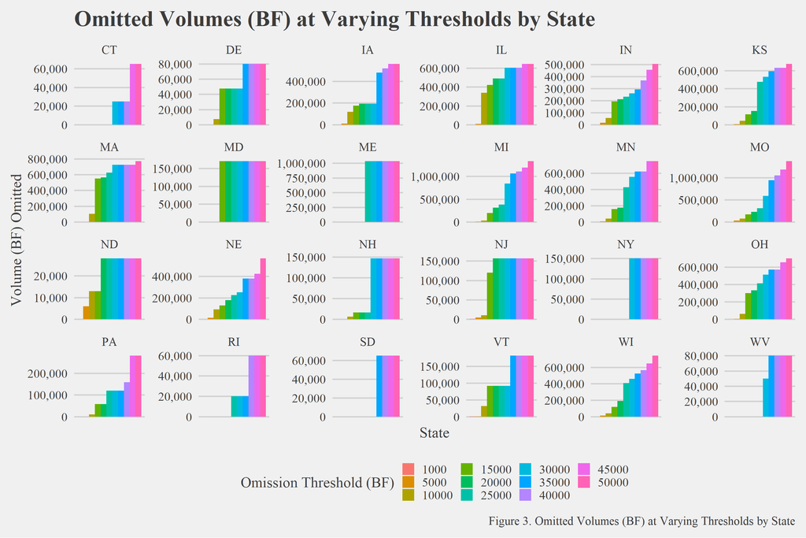

```r
Omission_Data %>%
  ggplot(aes(0, `Volume Omitted (BF)`, fill = factor(`Omission Threshold (BF)`))) +
  geom_col(position = 'dodge') +
  scale_y_continuous(labels = scales::comma) +
  scale_fill_discrete(name = "Omission Threshold (BF)") +
  facet_wrap(facets = vars(State), scales = 'free_y', ncol = 6) +
  labs(title = "Omitted Volumes (BF) at Varying Thresholds by State", y = "Omitted Volume (BF)", x = "State", caption = "Figure 3. Omitted Volumes (BF) at Varying Thresholds by State") +
  theme_fivethirtyeight(base_size = 20, base_family = 'serif') +
  theme(axis.text.x=element_blank(), axis.ticks.x=element_blank(),panel.grid.major.x = element_blank(), axis.title = element_text(family = 'serif', size = 20)) + ylab('Volume (BF) Omitted')
```

```r
# Omission Table
High_Vol_by_State <- TPO_Data %>%
  group_by(MILL_STATE) %>%
  filter(TOT_BF_LOG >= 8)

High_Vol_States = unique(High_Vol_by_State$MILL_STATE)
rm(High_Vol_by_State)

Omission_Table <- reactable(Omission_Data[,c(1:3,5:6)], groupBy = "State",  defaultPageSize = 24, outlined = TRUE, resizable = TRUE, wrap = TRUE, highlight = TRUE, theme = reactableTheme(
                           cellStyle = list(display = "flex", flexDirection = "column", justifyContent = "center"),
                           headerStyle = list(display = "flex", flexDirection = "column", justifyContent = "center")),
                           rowStyle = function(index) {
                             if (Omission_Data[index, "State"] %in% High_Vol_States) {
                               list(background = "yellow")
                             }
                             },
                           columns = list(
                            Mill_Count = colDef(name = "# of Mills Omitted", align = "center"),
                            State = colDef(align = "center"),
                            'Omission Threshold (BF)' = colDef(align = "center", format = colFormat(separators = TRUE)),
                            'Volume Omitted (BF)' = colDef(align = "center", format = colFormat(separators = TRUE, digits = 2)),
                            '% of Volume Omitted' = colDef(align = "center", format = colFormat(digits = 3))))

Omission_Table_Titled <- htmlwidgets::prependContent(Omission_Table, h2(class = "title", "Omitted Volumes (BF) at Varying Thresholds by State", style = "text-align: center"), h3(class = "caption", "Dropdown rows highlighted in yellow are within a State that contains at least one mill with a reported volume >= 100,000,000 BF", style = "text-align: center; font-size: 85%; font-weight: normal"))

Omission_Table_Titled
```

## Omitted Volumes (BF) at Varying Thresholds by State

### Dropdown rows highlighted in yellow are within a State that contains at least one mill with a reported volume >= 100,000,000 BF

| State | Omission Threshold (BF) | Volume Omitted (BF) | % of Volume Omitted | # of Mills Omitted |
| --- | --- | --- | --- | --- |
| CT | 1000 | 0 | 0 | 0 |
| CT | 5000 | 0 | 0 | 0 |
| CT | 10000 | 0 | 0 | 0 |
| CT | 15000 | 0 | 0 | 0 |
| CT | 20000 | 0 | 0 | 0 |
| CT | 25000 | 0 | 0 | 0 |
| CT | 30000 | 25015.35 | 0.0549525061425637 | 1 |
| CT | 35000 | 25015.35 | 0.0549525061425637 | 1 |
| CT | 40000 | 25015.35 | 0.0549525061425637 | 1 |
| CT | 45000 | 65039.91 | 0.142876515970666 | 2 |

[output cut: 254 more lines]

## 3.2 Histograms of Log(10) Volume

### 3.2.1 Histrogram Code & Output

The code below produces two histograms of reported volumes, using Logged MCF and Logged BF. Both are univariate, utilizing the columns “TOT_MCF_LOG” and “TOT_BF_LOG” respectively. These plots help to answer questions regarding the presence of reported mill volumes that are far outside of a normal range. A “normal” log MCF value would be < 4.2, while a “normal” log BF value would be < 8.

In taking a quick glance at the Logged BF plot, it is clear that there are at least 83 mills with reported volumes far outside of a “normal” range.

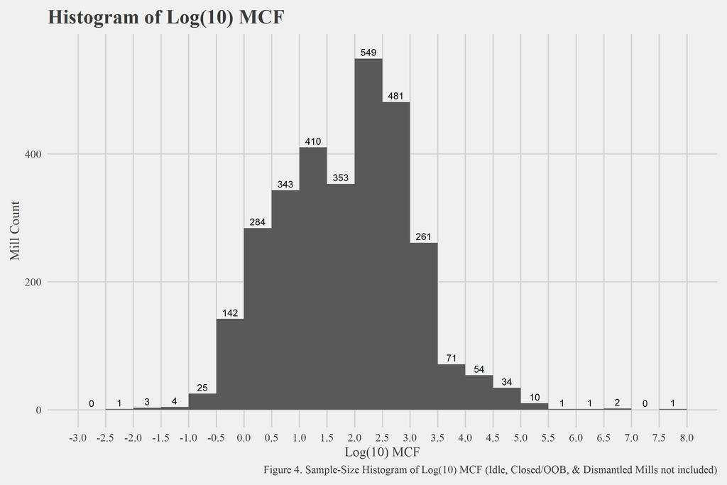

```r
#Create a histogram of Mill Volumes (Logged MCF)

Hist_Breaks_MCF <- c(seq(from = -3, to = 8, by = .5))

ggplot(TPO_Data, aes(TOT_MCF_LOG, label = ..count..), xlim = c(0, 8), ylim = c(0, 600)) +
  geom_histogram(breaks = Hist_Breaks_MCF, bins = 16) +
  scale_x_continuous(breaks= Hist_Breaks_MCF) +
  labs(title = "Histogram of Log(10) MCF", caption = "Figure 4. Sample-Size Histogram of Log(10) MCF (Idle, Closed/OOB, & Dismantled Mills not included)") +
  geom_text(stat="bin", nudge_y = 10, size=5, breaks = Hist_Breaks_MCF) +
  theme(text = element_text(family = "serif")) +
  theme_fivethirtyeight(base_size = 20, base_family = 'serif') +
  theme(axis.title = element_text(family = 'serif', size = 20)) + ylab('Mill Count') + xlab('Log(10) MCF')
```

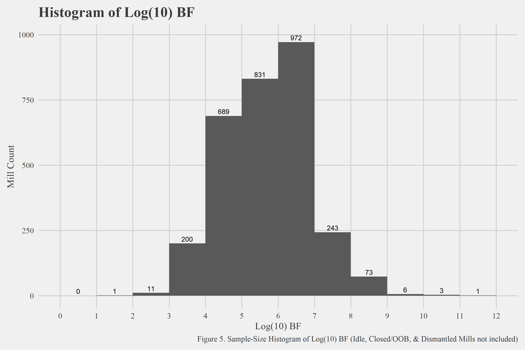

```r
#Create a histogram of Mill Volumes (Logged BF)

Hist_Breaks_BF <- c(seq(from = 0, to = 12, by = 1))

ggplot(TPO_Data, aes(TOT_BF_LOG, label = ..count..), xlim = c(0, 12), ylim = c(0, 1200)) +
  geom_histogram(breaks = Hist_Breaks_BF, binwidth = 1) +
  scale_x_continuous(breaks= Hist_Breaks_BF) +
  labs(title = "Histogram of Log(10) BF", caption = "Figure 5. Sample-Size Histogram of Log(10) BF (Idle, Closed/OOB, & Dismantled Mills not included)") +
  geom_text(stat="bin", nudge_y = 17,size=5,breaks = Hist_Breaks_BF) +
  theme_fivethirtyeight(base_size = 20, base_family = 'serif') +
  theme(axis.title = element_text(family = 'serif', size = 20)) + ylab('Mill Count') + xlab('Log(10) BF')
```

```r
#ggplot(TPO_Data, aes(TOT_BF_LOG), xlim = c(0, 12), ylim = c(0, 1200)) + geom_density(stat = 'density' ,bw = .5, fill = 'steelblue', aes(label = ..density..)) + geom_rug(alpha = .2) + scale_x_continuous(breaks= Hist_Breaks_BF) +labs(title = "Histogram of Log(10) BF", caption = "Figure 5. Sample-Size Histogram of Log(10) BF (Idle, Closed/OOB, & Dismantled Mills not included)") + theme_fivethirtyeight(base_size = 20, base_family = 'serif') + theme(axis.title = element_text(family = 'serif', size = 20)) + ylab('Proportion of In-Sample Mills') + xlab('Log(10) BF')
```

## 3.3 State Level Volume Plots

The scatter, box, and violin plots below utilize a host of variables, most of which required some sort of tidying prior to visualization.

### 3.3.1 Log(10) BF Volume Scatter, Box, and Violin Plots

These plots visualize reported mill volumes’ on a state-by-state basis. By breaking these volumes down by state, our FS partners are able to hone-in on states with the largest number of volume-outliers (i.e. Log(10) BF > 8). From the plots, it is clear that there are a few states that will need to be reviewed, these include ME, MI, & MN, among others.

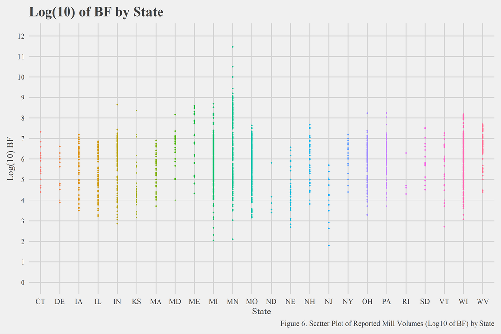

```r
#Create State-by-State boxplots and scatter plots for Logged BF Volume

ggplot(TPO_Data, aes(x = MILL_STATE, y = TOT_BF_LOG, color = MILL_STATE)) +
  geom_point(size = 1.2) +
  scale_y_continuous(breaks = Hist_Breaks_BF, limits = c(0,12)) +
  labs(title = "Log(10) of BF by State", y = "Log(10) of BF", x = "State", caption = "Figure 6. Scatter Plot of Reported Mill Volumes (Log10 of BF) by State") +
  theme_fivethirtyeight(base_size = 20, base_family = 'serif') +
  theme(axis.title = element_text(family = 'serif', size = 20), legend.position = "none") + ylab('Log(10) BF') + xlab('State')
```

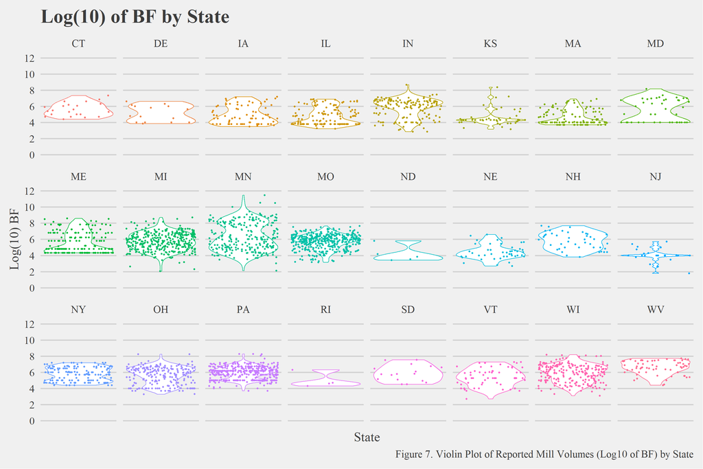

```r
ggplot(TPO_Data, aes(0, y = TOT_BF_LOG, color = MILL_STATE)) +
  geom_violin(width = 1, scale = 'count') +
  geom_jitter(width = 0.5, size = 1) +
  scale_y_continuous(breaks = c(seq(0,12,2)), limits = c(0,12)) +
  labs(title = "Log(10) of BF by State", caption = "Figure 7. Violin Plot of Reported Mill Volumes (Log10 of BF) by State") +
  theme_fivethirtyeight(base_size = 20, base_family = 'serif') +
  theme(axis.title = element_text(family = 'serif', size = 20), legend.position = "none", axis.text.x = element_blank(), panel.grid.major.x = element_blank()) + ylab('Log(10) BF') + xlab('State') +
  facet_wrap(facets = vars(MILL_STATE), ncol = 8)
```

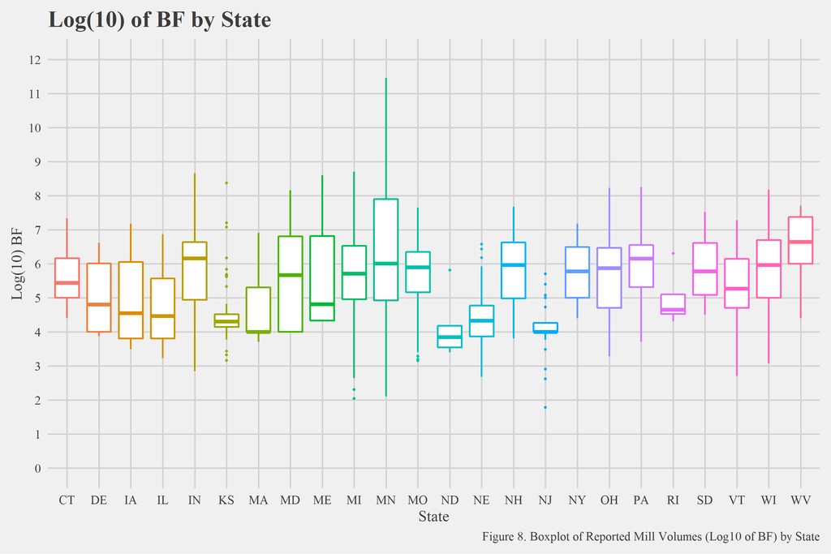

```r
ggplot(TPO_Data, aes(x = MILL_STATE, y = TOT_BF_LOG, color = MILL_STATE)) +
  geom_boxplot(outlier.size = 1.5, lwd=1.2) +
  scale_y_continuous(breaks = Hist_Breaks_BF, limits = c(0,12)) +
  labs(title = "Log(10) of BF by State", y = "Log(10) of BF", x = "State", caption = "Figure 8. Boxplot of Reported Mill Volumes (Log10 of BF) by State") +
  theme_fivethirtyeight(base_size = 20, base_family = 'serif') +
  theme(axis.title = element_text(family = 'serif', size = 20), legend.position = "none") + ylab('Log(10) BF') + xlab('State')
```

### 3.3.2 High Volume Plot

This bar chart depicts the number of volume-outliers (i.e. Log(10) BF > 8) on a state-by-state basis. States with no volume-outliers were not included in the plot.

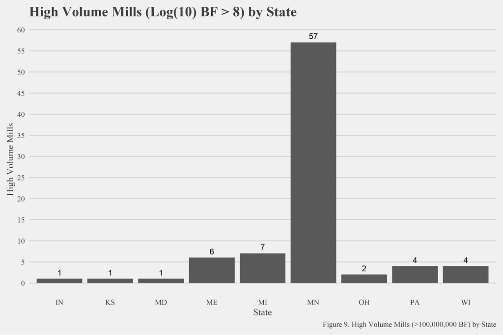

```r
#Create Bar Chart for High Volume Mills by State

TPO_Data %>%
  group_by(MILL_STATE) %>%
  filter(TOT_BF_LOG >= 8) %>%
  summarize("High_Volume_Mills" = n()) %>%
  ggplot(aes(x = MILL_STATE, y = High_Volume_Mills)) +
    geom_col() +
    geom_text(aes(label = High_Volume_Mills), size = 6 ,nudge_y = 1.5) +
    scale_y_continuous(breaks = c(seq(from = 0, to = 65, by = 5))) +
    theme_fivethirtyeight(base_size = 20, base_family = 'serif') +
    theme(axis.title = element_text(family = 'serif', size = 20), panel.grid.major.x = element_blank()) + ylab('High Volume Mills') + xlab('State') +
    labs(title = "High Volume Mills (Log(10) BF > 8) by State", caption = "Figure 9. High Volume Mills (>100,000,000 BF) by State")
```

### 3.3.3 Mill Type Plot

This bar chart depicts a breakdown of Mill “Types” on a state-by-state basis.

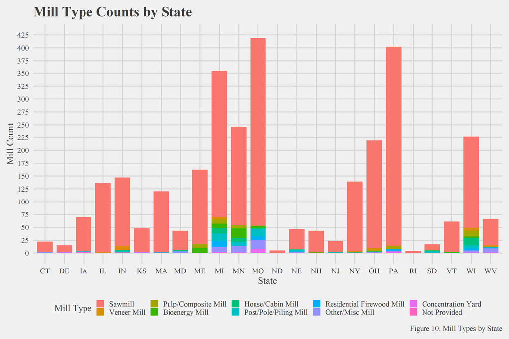

```r
#Create MTC_Summary

MTC_summary <- TPO_Data %>%
 mutate(MTC_Tidy = case_when(MTC %in% c(10,21,22,23,24,25,26) ~ "Sawmill",
                         MTC == 20 ~ "Veneer Mill",
                         MTC %in% c(30,40) ~ "Pulp/Composite Mill",
                         MTC == 50 ~ "Bioenergy Mill",
                         MTC == 60 ~ "House/Cabin Mill",
                         MTC %in% c(70,80,90) ~ "Post/Pole/Piling Mill",
                         MTC == 100 ~ "Residential Firewood Mill",
                         MTC %in% c(110,111) ~ "Other/Misc Mill",
                         MTC == 117 ~ "Concentration Yard",
                         is.na(MTC) ~ "Not Provided"))%>%
  group_by(MILL_STATE, MTC_Tidy) %>%
  arrange(as.factor(MTC_Tidy)) %>%
  summarize("Mill_Type_Count" = n())

#Create bar chart of Mill Type Counts by State

MTC_Tidy_Factor_Levels <- c("Sawmill", "Veneer Mill", "Pulp/Composite Mill", "Bioenergy Mill", "House/Cabin Mill", "Post/Pole/Piling Mill", "Residential Firewood Mill", "Other/Misc Mill", "Concentration Yard", "Not Provided")

ggplot(MTC_summary, aes(x = MILL_STATE, y = Mill_Type_Count, fill = factor(MTC_Tidy, levels = MTC_Tidy_Factor_Levels))) +
  geom_col(position = 'stack', width = .8) +
  labs(title = "Mill Type Counts by State", caption = "Figure 10. Mill Types by State") +
  scale_y_continuous(limits = c(0, 425), breaks = c(seq(from = 0, to = 425, by = 25))) +
  scale_fill_discrete(name = "Mill Type") +
  theme_fivethirtyeight(base_size = 20, base_family = 'serif') +
  theme(axis.title = element_text(family = 'serif', size = 20)) + ylab('Mill Count') + xlab('State')
```

# 4 Summary Statistics

## 4.1 State Level Means, Medians, & St. Deviations

The following chunk uses dplyr functions to measure a few meaningful values on a state-by-state basis.

```r
#Calculate means, medians, and standard deviations of logged volumes by state

TPO_summary <- TPO_Data %>%
  select(MILL_STATECD, MILL_STATE, MTC, TOT_MCF_LOG, TOT_BF_LOG) %>%
  group_by(MILL_STATE) %>%
  summarize(meanBF = mean(TOT_BF_LOG, na.rm = TRUE),
            medianBF = median(TOT_BF_LOG, na.rm = TRUE),
            meanMCF = mean(TOT_MCF_LOG, na.rm = TRUE),
            medianMCF = median(TOT_MCF_LOG, na.rm = TRUE),
            St_Dev = sd(TOT_BF_LOG, na.rm = TRUE),
            NumberofMills = n())

#Create table for means, medians, and standard deviations

kable(TPO_summary, digits = 4, align = "ccccccc", col.names = c("State", "Mean Log(10) BF", "Median Log(10) BF", "Mean Log(10) MCF", "Median Log(10) MCF", "Standard Deviation", "Mill Count"), caption = "Volume-based means, medians, and standard deviations for all mills (omissions not removed) by State. States highlighted in yellow contain at least one mill with a reported volume >= 100,000,000 BF") %>%
  kable_styling(font_size = 16) %>%
  row_spec(c(5,6,8,9:11,18,19,23), background = "yellow")
```

Table 2: Volume-based means, medians, and standard deviations for all mills (omissions not removed) by State. States highlighted in yellow contain at least one mill with a reported volume >= 100,000,000 BF

| State | Mean Log(10) BF | Median Log(10) BF | Mean Log(10) MCF | Median Log(10) MCF | Standard Deviation | Mill Count |
| --- | --- | --- | --- | --- | --- | --- |
| CT | 5.5946 | 5.4378 | 1.7930 | 1.6362 | 0.8204 | 22 |
| DE | 5.0969 | 4.8016 | 1.2953 | 1.0000 | 1.0085 | 15 |
| IA | 4.9398 | 4.5509 | 1.1382 | 0.7492 | 1.1110 | 70 |
| IL | 4.7821 | 4.4616 | 0.9805 | 0.6600 | 1.0647 | 136 |
| IN | 5.7586 | 6.1617 | 1.9570 | 2.3601 | 1.1764 | 147 |
| KS | 4.5832 | 4.3013 | 0.7816 | 0.4997 | 0.9912 | 48 |
| MA | 4.5912 | 4.0003 | 0.7896 | 0.1987 | 0.9057 | 120 |
| MD | 5.5059 | 5.6701 | 1.7043 | 1.8685 | 1.3804 | 43 |
| ME | 5.5991 | 4.8144 | 1.7974 | 1.0128 | 1.2836 | 162 |
| MI | 5.7111 | 5.7119 | 1.9095 | 1.9103 | 1.0814 | 354 |
| MN | 6.2930 | 6.0091 | 2.4914 | 2.2075 | 1.7166 | 246 |
| MO | 5.7202 | 5.8943 | 1.9186 | 2.0927 | 0.8908 | 419 |
| ND | 4.1555 | 3.8454 | 0.3539 | 0.0438 | 0.9736 | 5 |
| NE | 4.4404 | 4.3277 | 0.6388 | 0.5261 | 0.9163 | 46 |
| NH | 5.8028 | 5.9649 | 2.0011 | 2.1633 | 1.0444 | 43 |
| NJ | 4.0423 | 4.0003 | 0.2407 | 0.1987 | 0.8522 | 23 |
| NY | 5.7856 | 5.7784 | 1.9840 | 1.9768 | 0.8405 | 139 |
| OH | 5.5961 | 5.8753 | 1.7945 | 2.0737 | 1.0604 | 219 |
| PA | 5.9581 | 6.1510 | 2.1565 | 2.3494 | 0.7736 | 402 |
| RI | 4.9757 | 4.6501 | 1.1741 | 0.8485 | 0.8998 | 4 |
| SD | 5.8746 | 5.7797 | 2.0729 | 1.9780 | 0.9865 | 17 |
| VT | 5.4019 | 5.2720 | 1.6002 | 1.4704 | 1.0931 | 61 |
| WI | 5.8532 | 5.9688 | 2.0516 | 2.1672 | 1.0782 | 226 |
| WV | 6.5522 | 6.6467 | 2.7506 | 2.8451 | 0.8693 | 66 |

# 5 Comarison of Sample-Reported & 2020 Survey Response Volumes

The final step in this project is to compare the sample-reported volumes with survey-response volumes from the most recent iteration (2020, though surveyed in 2021). While much of the ‘tidying’ code is shown in the chunks below, some of the code could not be shown given the confidential nature of individual survey responses. The hidden sections include syntax to fix erroneous state/volume unit entries, and was done manually by parsing through the ‘TPO_Data_2020’ df.

To begin this process, the 2020 survey data is read in and saved as a df named ‘TPO_Data_2020’. In a hidden chunk that follows, a few erroneous state entries are fixed for individual mills.

```r
# Read 2020 TPO Data & rename problematic State entries

TPO_Data_2020 <- read_csv(file = "C:\\Users\\kenne\\Documents\\R_Workspace\\2020_TPO_Data.csv", col_select = c("MILL_NAME":"MILL_ZIP_CD", "MILL_TYPE_CD":"WOOD_PROCESSED_CD", "MILL_OUTPUT_CAPACITY_ANNUAL", "MILL_OUTPUT_CAP_ANNUAL_UNIT_CD", "AMOUNT":"RWAMT_UNIT_MEASURE_CD_OTHERTXT", "TPOID", "SW_LBSPERMBF":"HW_LBSPERCORD")) %>%
  select(-'MILL_PHONE')
```

The analysis continues below, first filtering the 2020 data set for idle, closed, or dismantled mills, storing these in a df named ‘Closed_OOB_Idle_2020. Next, the TPO sample-frame is joined to the 2020 df using the unique ID provided for each mill. Using the joined df, certain columns are selected, the df is arranged by state, the ’MILL_STATE’ column is edited to match the state provided within the sample. Within the same pipe the df is further filtered to only include mills that are active/NA, or those that reported being idle/closed/dismantled (‘MILL_STATUS_CD’ = 3, 4, or 5) but provided a volume (‘AMOUNT’). Finally, the Amount_Unit column is created based on entries in the ‘RWAMT_UNIT_MEASURE_CD’ column, and the df is once again filtered for mills whose ‘Amount_Unit’ column populated or who have provided an estimate of annual volume in the ‘MILL_OUTPUT_CAPACITY_ANNUAL’ column.

```r
# Create DF for Closed/OOB/Idle Responses in 2020

Closed_OOB_Idle_2020 <- TPO_Data_2020 %>%
  filter(MILL_STATUS_CD == 3 | MILL_STATUS_CD == 4 | MILL_STATUS_CD == 5 | is.na(MILL_STATUS_CD)) %>%
  arrange(desc(WOOD_PROCESSED_CD), desc(AMOUNT))

# Join Sample data to 2020 Data

TPO_Data_2020 <- TPO_Data_2020 %>%
  left_join(TPO_Data, by = c("TPOID"="TPOID_2020"), suffix = c("","_Sample")) %>%
  select(-c(MILL_LAT:SURVEY_YEAR))

# Tidy the 2020 Data

TPO_Data_2020 <- TPO_Data_2020 %>%
  select(MILL_NAME:TPOID, MILL_NBR:MILL_STATECD, MTC:TOT_BF_LOG, MILL_STATE_Sample) %>%
  arrange(MILL_STATE) %>%
  mutate(MILL_STATE = case_when(MILL_STATE != MILL_STATE_Sample ~ MILL_STATE_Sample,
                                 MILL_STATE == MILL_STATE_Sample ~ MILL_STATE)) %>%
  filter(MILL_STATUS_CD == 2 | is.na(MILL_STATUS_CD) | ((MILL_STATUS_CD == 3 | MILL_STATUS_CD == 4 | MILL_STATUS_CD == 5) & !is.na(AMOUNT))) %>%
  mutate(Amount_Unit = case_when(RWAMT_UNIT_MEASURE_CD == 1 ~ "BF Doyle",
                                 RWAMT_UNIT_MEASURE_CD == 2 ~ "BF Scribner",
                                 RWAMT_UNIT_MEASURE_CD == 5 ~ "BF 1/4 Inch",
                                 RWAMT_UNIT_MEASURE_CD == 6 ~ "BF LT",
                                 RWAMT_UNIT_MEASURE_CD == 11 ~ "MBF Doyle",
                                 RWAMT_UNIT_MEASURE_CD == 12 ~ "MBF Scribner",
                                 RWAMT_UNIT_MEASURE_CD == 15 ~ "MBF 1/4 Inch",
                                 RWAMT_UNIT_MEASURE_CD == 16 ~ "MBF LT",
                                 RWAMT_UNIT_MEASURE_CD == 21 ~ "Standard Cord",
                                 RWAMT_UNIT_MEASURE_CD == 22 ~ "Lake States Cord",
                                 RWAMT_UNIT_MEASURE_CD == 31 ~ "Green Tons",
                                 RWAMT_UNIT_MEASURE_CD == 61 ~ "Pieces",
                                 RWAMT_UNIT_MEASURE_CD == 99 ~ RWAMT_UNIT_MEASURE_CD_OTHERTXT,
                                 is.na(RWAMT_UNIT_MEASURE_CD) ~ RWAMT_UNIT_MEASURE_CD_OTHERTXT)) %>%
  filter(!is.na(Amount_Unit) | !is.na(MILL_OUTPUT_CAPACITY_ANNUAL)) %>%
  arrange(AMOUNT)
```

In another hidden chunk, the Amount_Unit_Tidy column is created by aggregating units of similar value. All BF measurements are coded as ‘BF’, MBF measurements as ‘MBF’, and MMBF units as ‘MMBF’. In the below chunk, the df is filtered to only include mills reporting BF units (BF/MBF/MMBF) whom also have reported a volume (‘AMOUNT’), or whom have reported an annual volume estimate in the ‘MILL_OUTPUT_CAPACITY_ANNUAL’ column. Then, the ‘AMOUNT’ column is converted to a numeric format, and the ‘Amount_BF’ column is created to convert volumes based on the unit provided.

```r
# Create DF for units in BF, MBF, & MMBF

TPO_Data_2020_BF <- TPO_Data_2020_Tidy %>%
  filter(Amount_Unit_Tidy %in% c('BF', 'MBF', 'MMBF'), !is.na(AMOUNT) | !is.na(MILL_OUTPUT_CAPACITY_ANNUAL))

# Convert Amounts to numeric

TPO_Data_2020_BF$AMOUNT <- as.numeric(as.character(TPO_Data_2020_BF$AMOUNT))


# Convert MBF/MMBF to BF

TPO_Data_2020_BF <- TPO_Data_2020_BF %>%
  mutate(AMOUNT_BF = case_when(Amount_Unit_Tidy == 'BF' ~ AMOUNT,
                            Amount_Unit_Tidy == 'MBF' ~ AMOUNT*1000,
                            Amount_Unit_Tidy == 'MMBF' ~ AMOUNT*1000000))
```

In a hidden chunk above a few erroneous volume entries are manually corrected. The chunk was hidden as it references a few mills’ names directly within the code.

The final chunks below create scatter/line plots to compare 2020 survey response volumes with those reported in the sample-frame. The first three plots each represent a range of 2020 response volumes (< 1,000,000 BF, 1,000,000 - 10,000,000 BF, and > 10,000,000 BF), while the final plot shows the full range of 2020 response volumes. Based on previous filtering, only mills reporting volumes on a board footage (BF, MBF, or MMBF) scale were included for these visualizations.

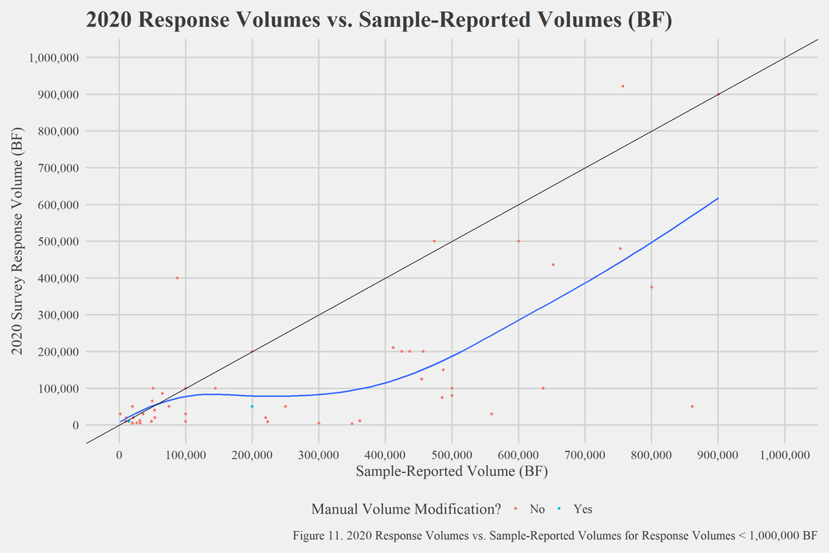

```r
TPO_Data_2020_BF %>%
  filter(AMOUNT_BF_Tidy < 1000000) %>%
  ggplot(aes(TOT_BF, AMOUNT_BF_Tidy)) +
  geom_point(aes(color = MILL_NAME %in% Edited_Mills)) +
  geom_smooth(se = FALSE) +
  geom_abline() +
  scale_x_continuous(labels = scales::comma,limits = c(0,1000000), breaks = c(seq(0,1000000,100000))) +
  scale_y_continuous(labels = scales::comma,limits = c(0,1000000), breaks = c(seq(0,1000000,100000))) +
  theme_fivethirtyeight(base_size = 20, base_family = 'serif') +
  theme(axis.title = element_text(family = 'serif', size = 20)) + ylab('2020 Survey Response Volume (BF)') + xlab('Sample-Reported Volume (BF)') +
  labs(title = "2020 Response Volumes vs. Sample-Reported Volumes (BF)", caption = "Figure 11. 2020 Response Volumes vs. Sample-Reported Volumes for Response Volumes < 1,000,000 BF") +
  scale_color_discrete(name = "Manual Volume Modification?", labels = c("No", "Yes"))
```

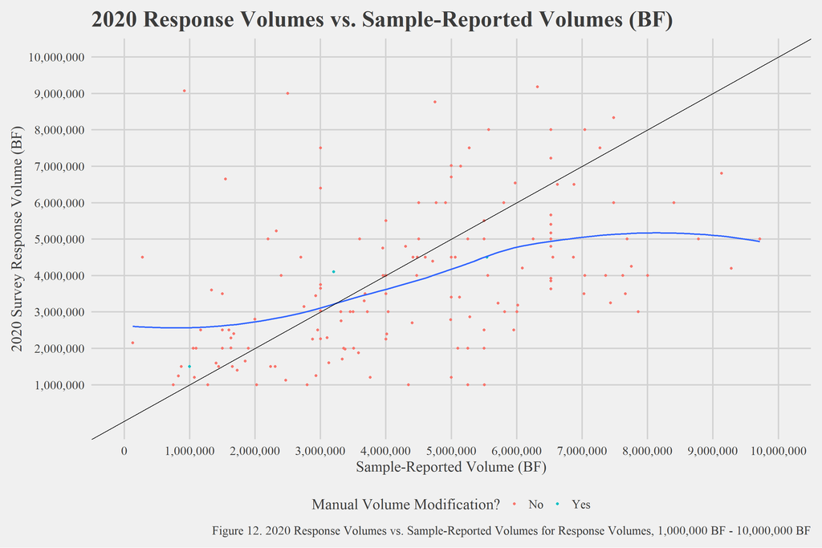

```r
TPO_Data_2020_BF %>%
  filter(AMOUNT_BF_Tidy >= 1000000 & AMOUNT_BF_Tidy < 10000000) %>%
  ggplot(aes(TOT_BF, AMOUNT_BF_Tidy)) +
  geom_point(aes(color = MILL_NAME %in% Edited_Mills)) +
  geom_smooth(se = FALSE) +
  geom_abline() +
  scale_x_continuous(labels = scales::comma, limits = c(0,10000000), breaks = c(seq(0,100000000,1000000))) +
  scale_y_continuous(labels = scales::comma, limits = c(0,10000000), breaks = c(seq(1000000,100000000,1000000))) +
  theme_fivethirtyeight(base_size = 20, base_family = 'serif') +
  theme(axis.title = element_text(family = 'serif', size = 20)) + ylab('2020 Survey Response Volume (BF)') + xlab('Sample-Reported Volume (BF)') +
  labs(title = "2020 Response Volumes vs. Sample-Reported Volumes (BF)", caption = "Figure 12. 2020 Response Volumes vs. Sample-Reported Volumes for Response Volumes, 1,000,000 BF - 10,000,000 BF") +
  scale_color_discrete(name = "Manual Volume Modification?", labels = c("No", "Yes"))
```

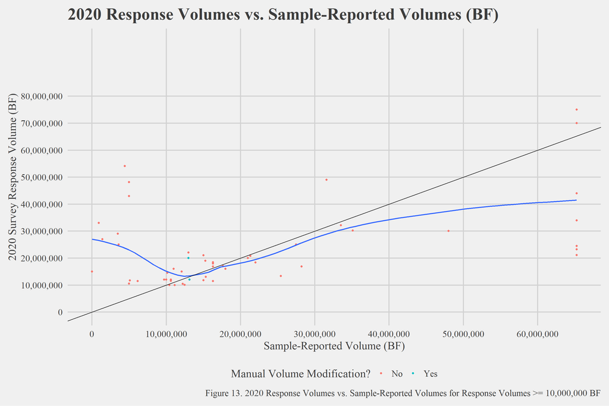

```r
TPO_Data_2020_BF %>%
  filter(AMOUNT_BF_Tidy >= 10000000) %>%
  ggplot(aes(TOT_BF, AMOUNT_BF_Tidy)) +
  geom_point(aes(color = MILL_NAME %in% Edited_Mills)) +
  geom_smooth(se = FALSE) +
  geom_abline() +
  scale_x_continuous(labels = scales::comma, breaks = c(seq(0, 80000000, 10000000))) +
  scale_y_continuous(labels = scales::comma, limits = c(0, 100000000), breaks = c(seq(0, 80000000, 10000000))) +
  theme_fivethirtyeight(base_size = 20, base_family = 'serif') +
  theme(axis.title = element_text(family = 'serif', size = 20)) + ylab('2020 Survey Response Volume (BF)') + xlab('Sample-Reported Volume (BF)') +
  labs(title = "2020 Response Volumes vs. Sample-Reported Volumes (BF)", caption = "Figure 13. 2020 Response Volumes vs. Sample-Reported Volumes for Response Volumes >= 10,000,000 BF") +
  scale_color_discrete(name = "Manual Volume Modification?", labels = c("No", "Yes"))
```

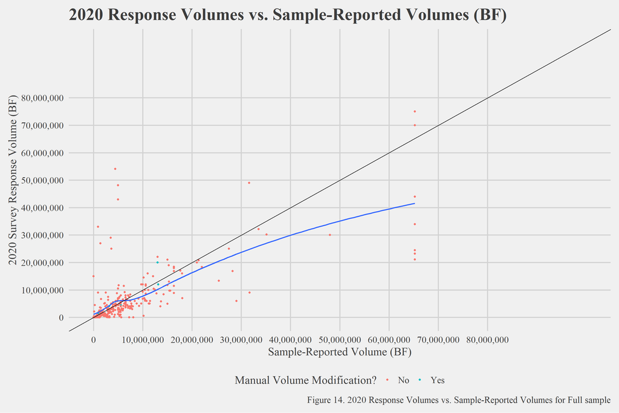

```r
# Full Sample Comparison

TPO_Data_2020_BF %>%
  filter(MILL_NAME != "SMITH FOREST PRODUCTS" & MILL_NAME != "BERG REINVIGORATIONS LLC" & MILL_NAME != "INDIANA VENEERS CORP") %>%
  ggplot(aes(TOT_BF, AMOUNT_BF_Tidy)) +
  geom_point(aes(color = MILL_NAME %in% Edited_Mills)) +
  geom_smooth(se = FALSE) +
  geom_abline() +
  #geom_text(aes(label = MILL_NAME)) +
  scale_x_continuous(labels = scales::comma, limits = c(0, 100000000), breaks = c(seq(0, 80000000, 10000000))) +
  scale_y_continuous(labels = scales::comma, limits = c(0, 100000000), breaks = c(seq(0, 80000000, 10000000))) +
  theme_fivethirtyeight(base_size = 20, base_family = 'serif') +
  theme(axis.title = element_text(family = 'serif', size = 20)) + ylab('2020 Survey Response Volume (BF)') + xlab('Sample-Reported Volume (BF)') +
  labs(title = "2020 Response Volumes vs. Sample-Reported Volumes (BF)", caption = "Figure 14. 2020 Response Volumes vs. Sample-Reported Volumes for Full sample") +
  scale_color_discrete(name = "Manual Volume Modification?", labels = c("No", "Yes"))
```

```r
rm(TPO_Data_2020, TPO_Data_2020_BF, TPO_Data_2020_Tidy, Closed_OOB_Idle_2020, Edited_Mills)
```

# 6 Conclusions & Next Steps

- What is missing from your Final Project?
  - The major piece of information missing from this analysis is how to handle high-volume-outliers. Specifically, because this analysis is attempting to measure the impact of setting a volume-based cut-off for survey inclusion, corrections to these (likely) incorrect volumes are necessary prior to gauging impact on the overall volume included in the sample. In other words, while we can adequately measure the number and % of mills that would be removed if using a cut-off volume, we cannot do accurately measure the impact on overall sample volume.
- What do you hope to accomplish between now and submission time?
  - I am hoping that between now and submission time, our partners within the USDA Forest Service are able to amend our existing sample frame, specifically to correct egregious high-volume outliers. With these amendments, the volume-based omission threshold analysis that I am running will provide a more accurate measure of impacts to the sample-frame as a whole. Additionally, if all outliers are addressed, measures surrounding percentage (or proportion) of total volume omitted at varying thresholds can also be included.

Comment on this article Share: